# Q2 Batch Data Analysis

In this problem, we will look into batch data; dynamic time-series of a finite duration. Batch manufacturing processes are very common in chemical, pharma, bioengineering and semiconductor industries such as baker’s yeast production, beer brewing and vaccines production.

In theory, a reactor is designed with temperature, pressure, level, pH control and multiple sensors that measure these variables among others. A perfect batch (again in theory) is one that is tightly controlled to the specifications and as a result the productivity and quality of the final product is optimized.

In real life, a typical batch is run from a few hours up to a week or two and a lot of things can go wrong during this period. There is always variability either because the process is very sensitive to minor fluctuations in some variables or the control of some variables failed for a period of time.

In a company that implements Data Analytics or Multivariate Statistical Process Control (MSPC) monitoring is typically implemented with the following steps:

1. Identify a number of reference, perfect historical batches (15-20), both in terms of high productivity/quality and minimum anomalies or fluctuations around the setpoints.
2. Create a PCA model of the perfect batches identified. This is your model.
3. Every time your site is running a new batch, fit your data online or as soon as your data infrastructure allows you to do so. Fitting will tell you whether your batch is similar to the perfect batches or it is deviating from the reference behaviour.

Next, you will follow these steps to build a Batch Statistical Process Control and implement it to monitor a new batch (we will assume that you got the data at the end of the batch and fit them to the model). The dataset is from a baker’s yeast production facility in Solna, Sweden capturing the last step of the fermentation.

## 2.1 Build a Batch Statistical Process Control model

```python
import  pandas as pd
import  numpy as np
import  matplotlib.pyplot as plt
import  seaborn as sns
from mpl_toolkits.mplot3d import Axes3D
from sklearn.decomposition import PCA
from sklearn.preprocessing import StandardScaler
from sklearn.preprocessing import MaxAbsScaler
```

### 1. Import the data from ’bakers yeast reference batches.xlsx’. Identify how many batches are in the data. What is the duration of each batch and how many data points are there per batch? How many variables are measured (including time)?

```python
Bakers = pd.read_excel('bakers_yeast_reference_batches.xlsx')
```

```python
Bakers.shape
```

```
(1328, 11)
```

```python
Bakers
```

|  | Unnamed: 0 | Primary ID | BatchID | Time | Ethanol | Temperature | Molasses flow | NH3 flow | Air flow | Level | pH |
| --- | --- | --- | --- | --- | --- | --- | --- | --- | --- | --- | --- |
| 0 | 249 | 250 | bb | 0.000000 | 0.05059 | 31.9580 | 212.32800 | 6.16453 | 1382.19 | 43.4194 | 5.85607 |
| 1 | 250 | 251 | bb | 0.166667 | 0.04930 | 31.5303 | 835.47600 | 29.78270 | 2084.42 | 43.4853 | 5.34603 |
| 2 | 251 | 252 | bb | 0.333333 | 0.04973 | 30.8220 | 910.15500 | 32.50710 | 2266.47 | 43.5628 | 5.18718 |
| 3 | 252 | 253 | bb | 0.500000 | 0.04915 | 30.1617 | 985.01100 | 36.37100 | 2446.84 | 43.6002 | 5.18043 |
| 4 | 253 | 254 | bb | 0.666667 | 0.04744 | 29.8891 | 1052.45000 | 39.26990 | 2636.96 | 43.6572 | 5.18145 |
| ... | ... | ... | ... | ... | ... | ... | ... | ... | ... | ... | ... |
| 1323 | 2568 | 2569 | Xa | 13.000000 | 0.00784 | 32.6918 | 386.12800 | 0.01424 | 6736.81 | 57.3615 | 6.15868 |
| 1324 | 2569 | 2570 | Xa | 13.166700 | 0.00652 | 32.7386 | 96.28380 | 0.00000 | 6742.49 | 57.4025 | 6.25613 |
| 1325 | 2570 | 2571 | Xa | 13.333300 | 0.00643 | 32.8174 | 44.09750 | 0.00712 | 6734.69 | 57.2948 | 6.31553 |
| 1326 | 2571 | 2572 | Xa | 13.500000 | 0.00644 | 32.8268 | 10.43010 | -0.00356 | 6202.63 | 57.3891 | 6.34270 |
| 1327 | 2572 | 2573 | Xa | 13.666700 | 0.00647 | 32.8321 | 2.55432 | 0.01781 | 5739.12 | 57.2948 | 6.34062 |

1328 rows × 11 columns

#### Number of Batches and Number of Data Points/Batch

```python
No_of_Batches = Bakers['BatchID'].value_counts()
No_of_Batches
```

```
bb    83
cb    83
db    83
eb    83
fb    83
gb    83
hb    83
ib    83
jb    83
kb    83
lb    83
Ma    83
Na    83
Ta    83
Va    83
Xa    83
Name: BatchID, dtype: int64
```

```python
No_of_Batches.count()
```

```
16
```

Using the value.count() function gives us the number of data points per batch. Using the count() function gives us the Number of Batches. Here:

```
The count = No. of Data points = 83.
No. of Batches = 16
```

#### The Total Duration of each Batch

```python
Batch_bb = Bakers.groupby('BatchID').get_group('bb').groupby('BatchID')['Time'].last().reset_index()
print(Batch_bb)

print('\n')

Batch_cb = Bakers.groupby('BatchID').get_group('cb').groupby('BatchID')['Time'].last().reset_index()
print(Batch_cb)
```

```
  BatchID     Time
0      bb  13.6667


  BatchID     Time
0      cb  13.6667
```

#### Number of Variables inlcuding Time

As observed from the extracted excel file above, there are 8 variables that are measured including Time.

### 2. Plot the variables time-profiles in a 2x4 subplot. Inspect the graphs (don’t just plot them). Look for potential outliers. Which variables have the largest variability? Which variables are tightly controlled?

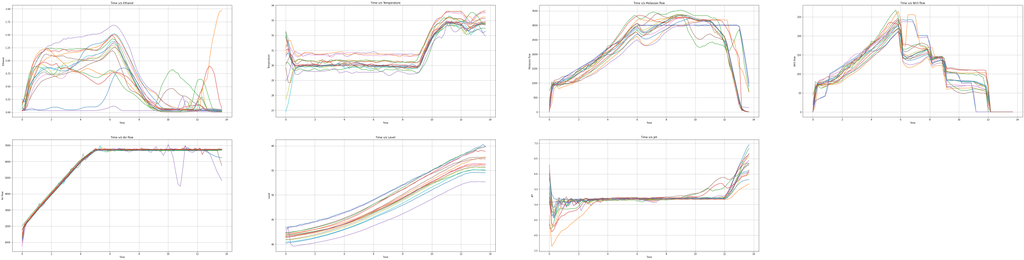

```python
plt.figure(figsize=(80,20))

for batch in ['bb', 'cb', 'db', 'eb', 'fb', 'gb', 'hb', 'ib', 'jb', 'kb', 'lb', 'Ma', 'Na', 'Ta', 'Va', 'Xa']:
    # for variable in [['Ethanol'], ['Temperature'], ['Molasses flow'], ['NH3 flow'], ['Air flow'], ['Level'], ['pH']]:
        batch = Bakers.groupby('BatchID').get_group(batch)['Ethanol']
        # print(bb)
        Time = Bakers.groupby('BatchID').get_group('bb')['Time']
        # print(Time)


        plt.subplot(2,4,1)
        plt.plot(Time,batch)
        plt.xlabel('Time')
        plt.ylabel('Ethanol')
        plt.title('Time v/s Ethanol')
        plt.grid(True)
        # plt.legend(loc='upper left');

for batch in ['bb', 'cb', 'db', 'eb', 'fb', 'gb', 'hb', 'ib', 'jb', 'kb', 'lb', 'Ma', 'Na', 'Ta', 'Va', 'Xa']:
    # for variable in [['Ethanol'], ['Temperature'], ['Molasses flow'], ['NH3 flow'], ['Air flow'], ['Level'], ['pH']]:
        batch = Bakers.groupby('BatchID').get_group(batch)['Temperature']
        # print(bb)
        Time = Bakers.groupby('BatchID').get_group('bb')['Time']
        # print(Time)


        plt.subplot(2,4,2)
        plt.plot(Time,batch)
        plt.xlabel('Time')
        plt.ylabel('Temperature')
        plt.title('Time v/s Temperature')
        plt.grid(True)
        # plt.legend(loc='upper left');

for batch in ['bb', 'cb', 'db', 'eb', 'fb', 'gb', 'hb', 'ib', 'jb', 'kb', 'lb', 'Ma', 'Na', 'Ta', 'Va', 'Xa']:
    # for variable in [['Ethanol'], ['Temperature'], ['Molasses flow'], ['NH3 flow'], ['Air flow'], ['Level'], ['pH']]:
        batch = Bakers.groupby('BatchID').get_group(batch)['Molasses flow']
        # print(bb)
        Time = Bakers.groupby('BatchID').get_group('bb')['Time']
        # print(Time)


        plt.subplot(2,4,3)
        plt.plot(Time,batch)
        plt.xlabel('Time')
        plt.ylabel('Molasses flow')
        plt.title('Time v/s Molasses flow')
        plt.grid(True)
        # plt.legend(loc='upper left');

for batch in ['bb', 'cb', 'db', 'eb', 'fb', 'gb', 'hb', 'ib', 'jb', 'kb', 'lb', 'Ma', 'Na', 'Ta', 'Va', 'Xa']:
    # for variable in [['Ethanol'], ['Temperature'], ['Molasses flow'], ['NH3 flow'], ['Air flow'], ['Level'], ['pH']]:
        batch = Bakers.groupby('BatchID').get_group(batch)['NH3 flow']
        # print(bb)
        Time = Bakers.groupby('BatchID').get_group('bb')['Time']
        # print(Time)


        plt.subplot(2,4,4)
        plt.plot(Time,batch)
        plt.xlabel('Time')
        plt.ylabel('NH3 flow')
        plt.title('Time v/s NH3 flow')
        plt.grid(True)
        # plt.legend(loc='upper left');

for batch in ['bb', 'cb', 'db', 'eb', 'fb', 'gb', 'hb', 'ib', 'jb', 'kb', 'lb', 'Ma', 'Na', 'Ta', 'Va', 'Xa']:
    # for variable in [['Ethanol'], ['Temperature'], ['Molasses flow'], ['NH3 flow'], ['Air flow'], ['Level'], ['pH']]:
        batch = Bakers.groupby('BatchID').get_group(batch)['Air flow']
        # print(bb)
        Time = Bakers.groupby('BatchID').get_group('bb')['Time']
        # print(Time)

        plt.subplot(2,4,5)
        plt.plot(Time,batch)
        plt.xlabel('Time')
        plt.ylabel('Air flow')
        plt.title('Time v/s Air flow')
        plt.grid(True)
        # plt.legend(loc='upper left');

for batch in ['bb', 'cb', 'db', 'eb', 'fb', 'gb', 'hb', 'ib', 'jb', 'kb', 'lb', 'Ma', 'Na', 'Ta', 'Va', 'Xa']:
    # for variable in [['Ethanol'], ['Temperature'], ['Molasses flow'], ['NH3 flow'], ['Air flow'], ['Level'], ['pH']]:
        batch = Bakers.groupby('BatchID').get_group(batch)['Level']
        # print(bb)
        Time = Bakers.groupby('BatchID').get_group('bb')['Time']
        # print(Time)

        plt.subplot(2,4,6)
        plt.plot(Time,batch)
        plt.xlabel('Time')
        plt.ylabel('Level')
        plt.title('Time v/s Level')
        plt.grid(True)
        # plt.legend(loc='upper left');

for batch in ['bb', 'cb', 'db', 'eb', 'fb', 'gb', 'hb', 'ib', 'jb', 'kb', 'lb', 'Ma', 'Na', 'Ta', 'Va', 'Xa']:
    # for variable in [['Ethanol'], ['Temperature'], ['Molasses flow'], ['NH3 flow'], ['Air flow'], ['Level'], ['pH']]:
        batch = Bakers.groupby('BatchID').get_group(batch)['pH']
        # print(bb)
        Time = Bakers.groupby('BatchID').get_group('bb')['Time']
        # print(Time)

        plt.subplot(2,4,7)
        plt.plot(Time,batch)
        plt.xlabel('Time')
        plt.ylabel('pH')
        plt.title('Time v/s pH')
        plt.grid(True)
#         plt.legend(loc='upper left');
```

#### Variables with the largest Variability

As observed from the graphs plotted above, the largest Variability is observed in the following variables:

- Ethanol
- Molasses flow
- NH3 flow

#### Variables that are tightly controlled

As observed from the graphs plotted above, the variables that are tightly controlled are as follows:

- Temperature
- 'Air flow' with only slight variability towards the end
- Level
- 'pH' with a fairly large amount of variablity at the start and towards the end

### 3. Select the features (including the Time column), pre-process the data and perform PCA with 5 principal components. Extract the scores and loadings.

### 4. In order to plot the scores-loading plot, you need to pivot the scores BatchID with index ’Time’ (use pandas pivot table).

#### Pre-processing the Data

```python
Bakers.drop(columns = ['Unnamed: 0', 'Primary ID'], inplace = True)
Bakers.set_index('BatchID', inplace = True)
Bakers
```

| BatchID | Time | Ethanol | Temperature | Molasses flow | NH3 flow | Air flow | Level | pH |
| --- | --- | --- | --- | --- | --- | --- | --- | --- |
| bb | 0.000000 | 0.05059 | 31.9580 | 212.32800 | 6.16453 | 1382.19 | 43.4194 | 5.85607 |
| bb | 0.166667 | 0.04930 | 31.5303 | 835.47600 | 29.78270 | 2084.42 | 43.4853 | 5.34603 |
| bb | 0.333333 | 0.04973 | 30.8220 | 910.15500 | 32.50710 | 2266.47 | 43.5628 | 5.18718 |
| bb | 0.500000 | 0.04915 | 30.1617 | 985.01100 | 36.37100 | 2446.84 | 43.6002 | 5.18043 |
| bb | 0.666667 | 0.04744 | 29.8891 | 1052.45000 | 39.26990 | 2636.96 | 43.6572 | 5.18145 |
| ... | ... | ... | ... | ... | ... | ... | ... | ... |
| Xa | 13.000000 | 0.00784 | 32.6918 | 386.12800 | 0.01424 | 6736.81 | 57.3615 | 6.15868 |
| Xa | 13.166700 | 0.00652 | 32.7386 | 96.28380 | 0.00000 | 6742.49 | 57.4025 | 6.25613 |
| Xa | 13.333300 | 0.00643 | 32.8174 | 44.09750 | 0.00712 | 6734.69 | 57.2948 | 6.31553 |
| Xa | 13.500000 | 0.00644 | 32.8268 | 10.43010 | -0.00356 | 6202.63 | 57.3891 | 6.34270 |
| Xa | 13.666700 | 0.00647 | 32.8321 | 2.55432 | 0.01781 | 5739.12 | 57.2948 | 6.34062 |

1328 rows × 8 columns

#### Pivoting the Table by Batch ID & Time

```python
Pivoted_bakers = Bakers.pivot_table(Bakers, index=['BatchID', 'Time'])
Pivoted_bakers
```

| BatchID | Time | Air flow | Ethanol | Level | Molasses flow | NH3 flow | Temperature | pH |
| --- | --- | --- | --- | --- | --- | --- | --- | --- |
| Ma | 0.000000 | 1403.82 | 0.17042 | 41.4770 | 69.20750 | 0.11429 | 31.1189 | 4.65089 |
|  | 0.166667 | 1961.74 | 0.27765 | 41.4699 | 284.41700 | 15.12140 | 31.6729 | 3.64269 |
|  | 0.333333 | 2250.15 | 0.37221 | 41.5207 | 806.23400 | 65.36790 | 31.6595 | 3.75869 |
|  | 0.500000 | 2450.60 | 0.66183 | 41.6340 | 909.24400 | 73.92140 | 31.1309 | 3.91439 |
|  | 0.666667 | 2648.56 | 0.89476 | 41.6714 | 800.71300 | 64.96430 | 30.7486 | 4.03618 |
| ... | ... | ... | ... | ... | ... | ... | ... | ... |
| lb | 13.000000 | 6740.09 | 0.04382 | 54.5975 | 445.51600 | 0.01424 | 32.6744 | 5.69131 |
|  | 13.166700 | 6754.46 | 0.04299 | 54.6020 | 115.86700 | 0.03917 | 32.7305 | 5.75258 |
|  | 13.333300 | 6752.77 | 0.04094 | 54.5521 | 52.47000 | 0.00712 | 32.7867 | 5.78561 |
|  | 13.500000 | 6751.62 | 0.03920 | 54.5289 | 10.71400 | 0.02137 | 32.8121 | 5.80288 |
|  | 13.666700 | 6734.95 | 0.03826 | 54.5494 | -0.35477 | 0.01424 | 32.8415 | 5.81509 |

1328 rows × 7 columns

#### Exploratory Data analysis

- Scatter Plot
- Correlation

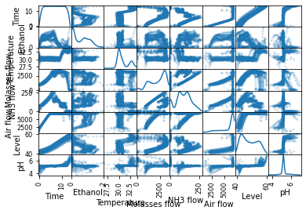

```python
# from pandas.plotting import scatter_matrix
pd.plotting.scatter_matrix(Bakers, alpha=0.2, diagonal = 'kde');

corr = Pivoted_bakers.corr()
```

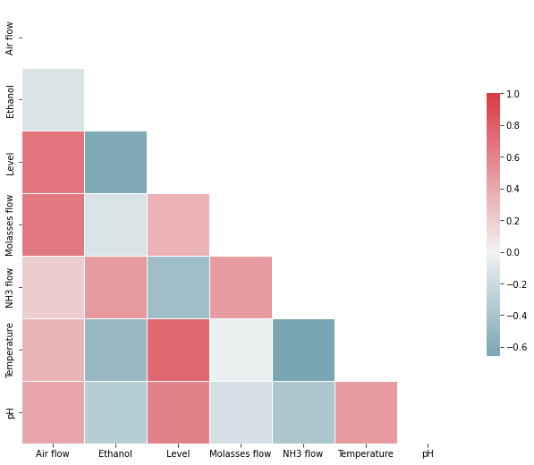

```python
# Generate a mask for the upper triangle
mask = np.zeros_like(corr, dtype=bool)
mask[np.triu_indices_from(mask)] = True

# Set up the matplotlib figure
f, ax = plt.subplots(figsize=(11, 9))

# Generate a custom diverging colormap
cmap = sns.diverging_palette(220, 10, as_cmap=True)

# Draw the heatmap with the mask and correct aspect ratio
sns.heatmap(corr, mask=mask, cmap=cmap, vmax=1, center=0,
            square=True, linewidths=.5, cbar_kws={"shrink": .6})
plt.show()
```

#### Standardize the Data

```python
# scaler = StandardScaler()
# scaler
# Bakers_scaled = scaler.fit_transform(Pivoted_bakers)
# Bakers_scaled

# The above standardizing function can be abriviated into the following function.

Bakers_scaled = StandardScaler().fit_transform(Pivoted_bakers)

Bakers_scaled
```

```
array([[-3.09321271, -0.78866551, -1.33049195, ..., -1.69141055,
         0.17218901, -1.81870204],
       [-2.70508822, -0.56365294, -1.33182292, ..., -1.46057072,
         0.6170452 , -4.93119547],
       [-2.50445195, -0.36522724, -1.32229988, ..., -0.68767748,
         0.60628514, -4.57308276],
       ...,
       [ 0.62785577, -1.06036771,  1.12058599, ..., -1.69305905,
         1.51141491,  1.68438122],
       [ 0.62705575, -1.06401895,  1.11623688, ..., -1.69283985,
         1.53181085,  1.7376968 ],
       [ 0.61545904, -1.06599145,  1.12007984, ..., -1.69294953,
         1.55541874,  1.77539125]])
```

```python
# Confirming the mean of the scaled columns after the function.
# NOTE: axis = 0 is for Columns
# NOTE: axis = 1 is for Rows/Index

Bakers_scaled.mean(axis = 0)
```

```
array([ 1.07009448e-16, -1.81916062e-16,  6.31355744e-16,  0.00000000e+00,
       -7.49066137e-17,  1.08079543e-15, -1.30016480e-15])
```

```python
# Confirming the std of the scaled columns after the function.

Bakers_scaled.std(axis = 0)
```

```
array([1., 1., 1., 1., 1., 1., 1.])
```

```python
Bakers_scaled.shape
```

```
(1328, 7)
```

#### Performing PCA with 5 PCs

```python
pca = PCA(n_components = 5, svd_solver = 'full')

Bakers_scores = pca.fit_transform(Bakers_scaled)
```

```python
# Pottery scores

Bakers_scores.shape
```

```
(1328, 5)
```

#### Extracting the scores in the form of Pandas Dataframe (1328 rows x 5 columns (scores))

```python
# Scores are meant to reproduce the index/rows's data in the form of PCA.

Bakers_scores_pd = pd.DataFrame(data = Bakers_scores,
                                        columns = ['PC1', 'PC2', 'PC3', 'PC4', 'PC5'],
                                        index = Pivoted_bakers.index)
```

```python
Bakers_scores_pd
```

| BatchID | Time | PC1 | PC2 | PC3 | PC4 | PC5 |
| --- | --- | --- | --- | --- | --- | --- |
| Ma | 0.000000 | -1.610232 | 4.112453 | 1.891981 | -0.385884 | -0.222938 |
|  | 0.166667 | -2.642548 | 3.448596 | 3.722107 | -2.295239 | -0.589393 |
|  | 0.333333 | -2.724030 | 2.604524 | 3.415466 | -2.097890 | -0.846085 |
|  | 0.500000 | -2.946707 | 2.309377 | 2.705208 | -1.964470 | -0.468704 |
|  | 0.666667 | -3.048907 | 2.315431 | 2.092796 | -1.932703 | -0.096525 |
| ... | ... | ... | ... | ... | ... | ... |
| lb | 13.000000 | 2.779712 | 1.950836 | -0.795291 | 0.053360 | -0.320854 |
|  | 13.166700 | 2.846843 | 2.188168 | -1.038958 | 0.141266 | -0.454775 |
|  | 13.333300 | 2.898132 | 2.247380 | -1.123720 | 0.171792 | -0.502976 |
|  | 13.500000 | 2.923235 | 2.283639 | -1.170470 | 0.191135 | -0.529803 |
|  | 13.666700 | 2.947149 | 2.303007 | -1.193378 | 0.198863 | -0.545272 |

1328 rows × 5 columns

#### Extracting the loadings in the form of Pandas DataFrame, based on the Columns, new dimension on the PCs

```python
# Loadings are meant to reproduce the column's data in the form of PCA.

Bakers_loadings_pd = pd.DataFrame(data = pca.components_.T
                           ,columns = ['PC1', 'PC2', 'PC3', 'PC4', 'PC5']
                           ,index = Pivoted_bakers.columns)

Bakers_loadings_pd
```

|  | PC1 | PC2 | PC3 | PC4 | PC5 |
| --- | --- | --- | --- | --- | --- |
| Air flow | 0.304539 | -0.534218 | -0.281282 | -0.118465 | -0.039017 |
| Ethanol | -0.382376 | -0.099427 | -0.606058 | -0.585936 | 0.279054 |
| Level | 0.522619 | -0.146715 | 0.033023 | -0.035993 | 0.256679 |
| Molasses flow | 0.090831 | -0.637390 | 0.348280 | -0.063288 | 0.320365 |
| NH3 flow | -0.332102 | -0.503056 | -0.118325 | 0.248487 | -0.645941 |
| Temperature | 0.465809 | 0.135141 | 0.037459 | -0.581767 | -0.578083 |
| pH | 0.390376 | 0.074869 | -0.644811 | 0.486977 | 0.025870 |

```python
# Definiting a function to customize the plot of the scores-loadings plot.

def myplot(scores,loadings,loading_labels=None,score_labels=None):

#     adjusting the scores to fit in (-1,1)
    xt = scores[:,0]
    yt = scores[:,1]
    n = loadings.shape[0]
    scalext = 1.0/(xt.max() - xt.min())
    scaleyt = 1.0/(yt.max() - yt.min())
    xt_scaled = xt * scalext
    yt_scaled = yt * scaleyt

#     adjusting the loadings to fit in (-1,1)
    p = loadings
    p_scaled = MaxAbsScaler().fit_transform(p)

#     Plotting the scores (i.e. the Lines) of the batches
    for batch in ['bb', 'cb', 'db', 'eb', 'fb', 'gb', 'hb', 'ib', 'jb', 'kb', 'lb', 'Ma', 'Na', 'Ta', 'Va', 'Xa']:
        PC1 = Bakers_scores_pd.loc[[batch], ['PC1']].to_numpy()
        PC2 = Bakers_scores_pd.loc[[batch], ['PC2']].to_numpy()

#         Bring the adjusting parameters from above into the loop so it scales the plot
        xt = PC1
        yt = PC2
        scalext = 1.0/(xt.max() - xt.min())
        scaleyt = 1.0/(yt.max() - yt.min())
        xt_scaled = xt * scalext
        yt_scaled = yt * scaleyt

#       print(PC1)
#       print(PC2)
#       PC1.to_numpy()

        plt.plot(xt_scaled,yt_scaled, label = batch, linestyle = '-', linewidth = '1')

#   Plotting the loadings and thier respective vectors
    for i in range(n):
        plt.arrow(0, 0, p_scaled[i,0], p_scaled[i,1], color = 'r',alpha = 0.5)
        if loading_labels is None:
            plt.text(p_scaled[i,0], p_scaled[i,1], "Var" + (i+1), color = 'g', ha = 'center', va = 'center')
        else:
            plt.text(p_scaled[i,0], p_scaled[i,1], loading_labels[i], color = 'r', ha = 'center', va = 'center', size=16)

#     plt.xlim(-1,1)
#     plt.ylim(-1.5,1)
    plt.xlabel("PC{}".format(1), fontsize=20);
    plt.ylabel("PC{}".format(2), fontsize=20);
    plt.tick_params(labelsize=16)
    plt.grid()
```

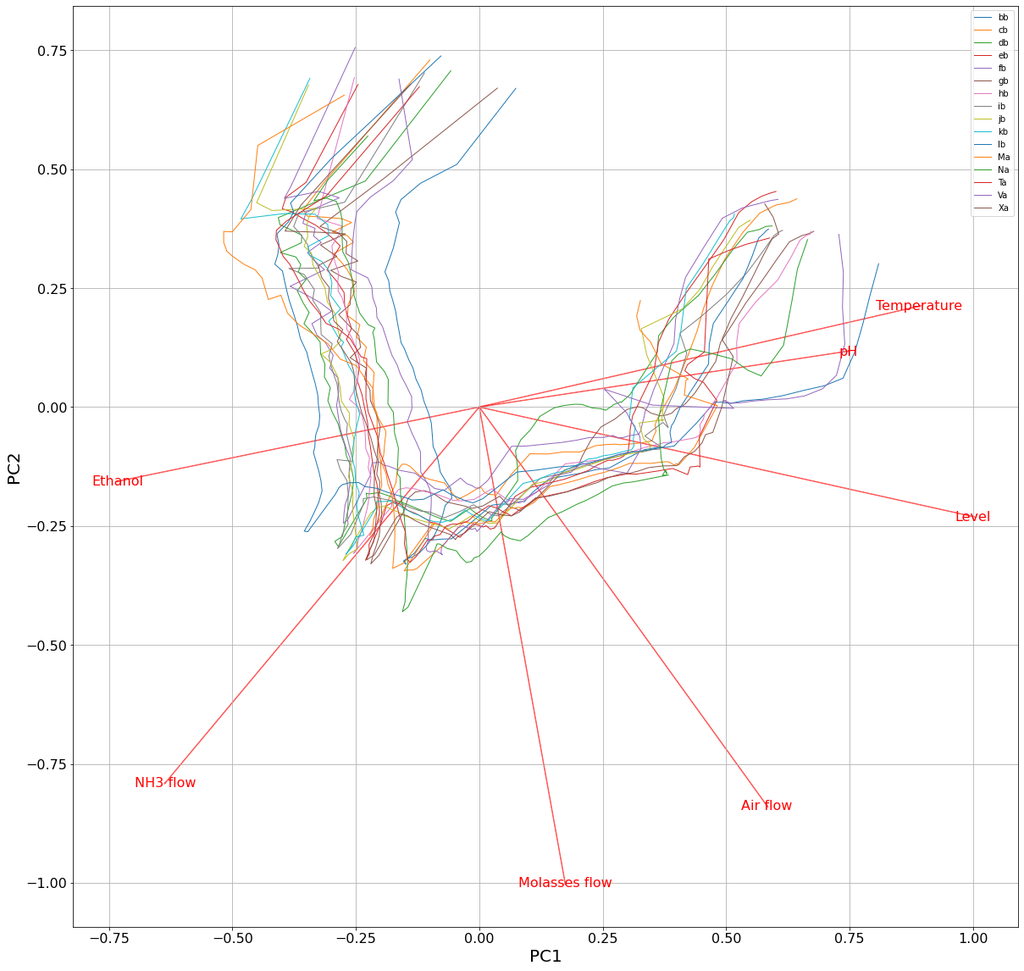

```python
plt.rcParams["figure.figsize"] = [20,20]
myplot(Bakers_scores[:,:2], Bakers_loadings_pd.iloc[:,:2],
       loading_labels = Bakers_loadings_pd.index,
       score_labels = Bakers_scores_pd.index)
plt.legend()
plt.show()
```

### 6. Explain this graph. In which quarter do the batches start and end? What happens at the kink where the direction of the lines changes? Can you tell from this graph which variables do not change in the first phase and which in the second phase?

The batches start in the 1st quater (top-left), and end in the 2nd quater (top-right).

Except kb and cb the rest were following the trend and do not change in both phases

### 7. Plot the cumulative explained variance. How much variance do the first two principal components capture?

#### Some PCA diagnostics that show and explain the Varience

```python
pca.explained_variance_
```

```
array([3.32090419, 2.00473959, 0.8247449 , 0.50662174, 0.18273344])
```

```python
pca.explained_variance_ratio_*100
```

```
array([47.40576443, 28.61757132, 11.77319792,  7.23200348,  2.60851198])
```

#### Plotting the variance graph

```python
pca = PCA(n_components = 5, svd_solver = 'full')
```

```python
pca.fit(Bakers_scaled)
```

```
PCA(n_components=5, svd_solver='full')
```

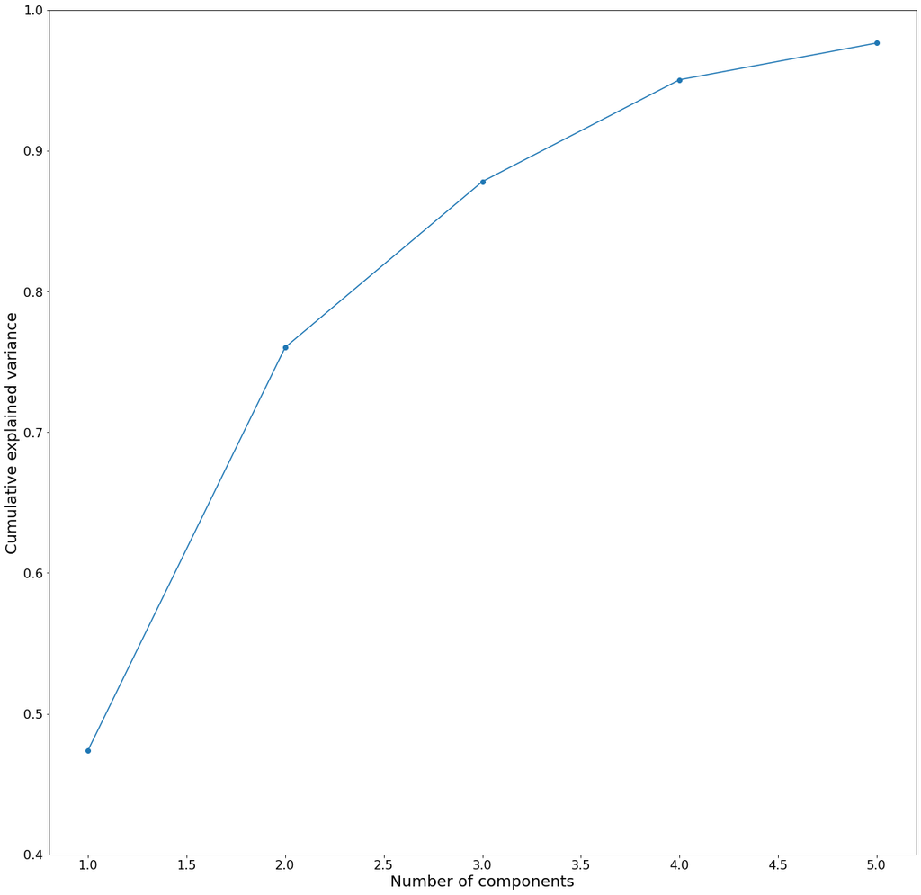

```python
plt.plot(range(1,pca.n_components+1), np.cumsum(pca.explained_variance_ratio_),'-o')
plt.xlabel('Number of components', fontsize=20)
plt.ylabel('Cumulative explained variance', fontsize=20);
plt.tick_params(labelsize=16)
plt.ylim(0.4,1)
plt.show()
```

The plot above shows the cumalative varience that has been captured by the PCA in total along with how much variene each PC covers.

## Use the model to monitor running batches

The goal of building an unsupervised model is to monitor the running batches. Your site runs two reactors in parallel and here you will fit the data from these two reactors to the model previously built and identify potential problems and outliers.

Ideally, in most industries you have the data available online and you get a new data point every minute or so. Then you fit every coming point to the model and overlay it with the graph from the previous section.

### 1. Load the data from the file ’todays batches.xlsx’ and repeat the same procedure as in the steps 3-4 of the previous section with the exception of the PCA modeling. Here, instead of fit the data to the model and transform, you will only transform them with the model object you created in the previous section.

```python
Todays_Batch = pd.read_excel('todays_batches.xlsx')
```

```python
Todays_Batch.shape
```

```
(166, 11)
```

```python
Todays_Batch
```

|  | Unnamed: 0 | Primary ID | BatchID | Time | Ethanol | Temperature | Molasses flow | NH3 flow | Air flow | Level | pH |
| --- | --- | --- | --- | --- | --- | --- | --- | --- | --- | --- | --- |
| 0 | 2573 | 2574 | Ya | 0.000000 | 0.30350 | 29.0885 | -0.70954 | 0.00356 | 1250.69 | 41.9216 | 4.86282 |
| 1 | 2574 | 2575 | Ya | 0.166667 | 0.41224 | 29.5509 | -1.49002 | 0.00712 | 2040.08 | 41.9911 | 4.00324 |
| 2 | 2575 | 2576 | Ya | 0.333333 | 1.16614 | 29.9639 | -1.63193 | 0.00712 | 2235.08 | 42.3624 | 4.05839 |
| 3 | 2576 | 2577 | Ya | 0.500000 | 2.22696 | 29.9746 | 1280.07000 | 82.08680 | 2419.08 | 42.8531 | 4.35465 |
| 4 | 2577 | 2578 | Ya | 0.666667 | 3.13590 | 29.9466 | 844.09600 | 74.65800 | 2603.53 | 43.2146 | 4.76967 |
| ... | ... | ... | ... | ... | ... | ... | ... | ... | ... | ... | ... |
| 161 | 2734 | 2735 | Za | 13.000000 | 0.01637 | 33.2882 | 301.55000 | 0.05000 | 6794.76 | 57.2191 | 6.38039 |
| 162 | 2735 | 2736 | Za | 13.166700 | 0.01575 | 33.3834 | 161.95900 | 0.04286 | 6820.50 | 57.2289 | 6.48979 |
| 163 | 2736 | 2737 | Za | 13.333300 | 0.01512 | 33.4438 | 75.58330 | 0.03214 | 6698.80 | 57.2021 | 6.55989 |
| 164 | 2737 | 2738 | Za | 13.500000 | 0.01444 | 33.4531 | 61.79870 | 0.06429 | 6775.14 | 57.0425 | 6.59559 |
| 165 | 2738 | 2739 | Za | 13.666700 | 0.01386 | 33.4518 | 54.06950 | 0.05357 | 6749.58 | 57.2048 | 6.61546 |

166 rows × 11 columns

```python
No_of_Todays_Batch = Todays_Batch["BatchID"].value_counts()
No_of_Todays_Batch
```

```
Ya    83
Za    83
Name: BatchID, dtype: int64
```

```python
No_of_Todays_Batch.count()
```

```
2
```

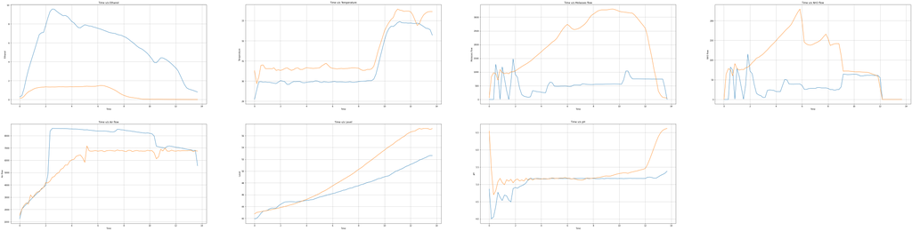

```python
plt.figure(figsize=(80,20))

for batch in ['Ya', 'Za']:
    # for variable in [['Ethanol'], ['Temperature'], ['Molasses flow'], ['NH3 flow'], ['Air flow'], ['Level'], ['pH']]:
        batch = Todays_Batch.groupby('BatchID').get_group(batch)['Ethanol']
        # print(bb)
        Time = Todays_Batch.groupby('BatchID').get_group('Ya')['Time']
        # print(Time)


        plt.subplot(2,4,1)
        plt.plot(Time,batch)
        plt.xlabel('Time')
        plt.ylabel('Ethanol')
        plt.title('Time v/s Ethanol')
        plt.grid(True)
        # plt.legend(loc='upper left');

for batch in ['Ya', 'Za']:
    # for variable in [['Ethanol'], ['Temperature'], ['Molasses flow'], ['NH3 flow'], ['Air flow'], ['Level'], ['pH']]:
        batch = Todays_Batch.groupby('BatchID').get_group(batch)['Temperature']
        # print(bb)
        Time = Todays_Batch.groupby('BatchID').get_group('Ya')['Time']
        # print(Time)


        plt.subplot(2,4,2)
        plt.plot(Time,batch)
        plt.xlabel('Time')
        plt.ylabel('Temperature ')
        plt.title('Time v/s Temperature')
        plt.grid(True)
        # plt.legend(loc='upper left');

for batch in ['Ya', 'Za']:
    # for variable in [['Ethanol'], ['Temperature'], ['Molasses flow'], ['NH3 flow'], ['Air flow'], ['Level'], ['pH']]:
        batch = Todays_Batch.groupby('BatchID').get_group(batch)['Molasses flow']
        # print(bb)
        Time = Todays_Batch.groupby('BatchID').get_group('Ya')['Time']
        # print(Time)


        plt.subplot(2,4,3)
        plt.plot(Time,batch)
        plt.xlabel('Time')
        plt.ylabel('Molasses flow')
        plt.title('Time v/s Molasses flow')
        plt.grid(True)
        # plt.legend(loc='upper left');

for batch in ['Ya', 'Za']:
    # for variable in [['Ethanol'], ['Temperature'], ['Molasses flow'], ['NH3 flow'], ['Air flow'], ['Level'], ['pH']]:
        batch = Todays_Batch.groupby('BatchID').get_group(batch)['NH3 flow']
        # print(bb)
        Time = Todays_Batch.groupby('BatchID').get_group('Ya')['Time']
        # print(Time)


        plt.subplot(2,4,4)
        plt.plot(Time,batch)
        plt.xlabel('Time')
        plt.ylabel('NH3 flow')
        plt.title('Time v/s NH3 flow')
        plt.grid(True)
        # plt.legend(loc='upper left');

for batch in ['Ya', 'Za']:
    # for variable in [['Ethanol'], ['Temperature'], ['Molasses flow'], ['NH3 flow'], ['Air flow'], ['Level'], ['pH']]:
        batch = Todays_Batch.groupby('BatchID').get_group(batch)['Air flow']
        # print(bb)
        Time = Todays_Batch.groupby('BatchID').get_group('Ya')['Time']
        # print(Time)


        plt.subplot(2,4,5)
        plt.plot(Time,batch)
        plt.xlabel('Time')
        plt.ylabel('Air flow')
        plt.title('Time v/s Air flow')
        plt.grid(True)
        # plt.legend(loc='upper left');

for batch in ['Ya', 'Za']:
    # for variable in [['Ethanol'], ['Temperature'], ['Molasses flow'], ['NH3 flow'], ['Air flow'], ['Level'], ['pH']]:
        batch = Todays_Batch.groupby('BatchID').get_group(batch)['Level']
        # print(bb)
        Time = Todays_Batch.groupby('BatchID').get_group('Ya')['Time']
        # print(Time)


        plt.subplot(2,4,6)
        plt.plot(Time,batch)
        plt.xlabel('Time')
        plt.ylabel('Level')
        plt.title('Time v/s Level')
        plt.grid(True)
        # plt.legend(loc='upper left');

for batch in ['Ya', 'Za']:
    # for variable in [['Ethanol'], ['Temperature'], ['Molasses flow'], ['NH3 flow'], ['Air flow'], ['Level'], ['pH']]:
        batch = Todays_Batch.groupby('BatchID').get_group(batch)['pH']
        # print(bb)
        Time = Todays_Batch.groupby('BatchID').get_group('Ya')['Time']
        # print(Time)


        plt.subplot(2,4,7)
        plt.plot(Time,batch)
        plt.xlabel('Time')
        plt.ylabel('pH')
        plt.title('Time v/s pH')
        plt.grid(True)
        # plt.legend(loc='upper left');
```

#### Preprocessing the Data

```python
Todays_Batch.drop(columns = ['Unnamed: 0', 'Primary ID'], inplace = True)
Todays_Batch.set_index('BatchID', inplace = True)
Todays_Batch
```

| BatchID | Time | Ethanol | Temperature | Molasses flow | NH3 flow | Air flow | Level | pH |
| --- | --- | --- | --- | --- | --- | --- | --- | --- |
| Ya | 0.000000 | 0.30350 | 29.0885 | -0.70954 | 0.00356 | 1250.69 | 41.9216 | 4.86282 |
| Ya | 0.166667 | 0.41224 | 29.5509 | -1.49002 | 0.00712 | 2040.08 | 41.9911 | 4.00324 |
| Ya | 0.333333 | 1.16614 | 29.9639 | -1.63193 | 0.00712 | 2235.08 | 42.3624 | 4.05839 |
| Ya | 0.500000 | 2.22696 | 29.9746 | 1280.07000 | 82.08680 | 2419.08 | 42.8531 | 4.35465 |
| Ya | 0.666667 | 3.13590 | 29.9466 | 844.09600 | 74.65800 | 2603.53 | 43.2146 | 4.76967 |
| ... | ... | ... | ... | ... | ... | ... | ... | ... |
| Za | 13.000000 | 0.01637 | 33.2882 | 301.55000 | 0.05000 | 6794.76 | 57.2191 | 6.38039 |
| Za | 13.166700 | 0.01575 | 33.3834 | 161.95900 | 0.04286 | 6820.50 | 57.2289 | 6.48979 |
| Za | 13.333300 | 0.01512 | 33.4438 | 75.58330 | 0.03214 | 6698.80 | 57.2021 | 6.55989 |
| Za | 13.500000 | 0.01444 | 33.4531 | 61.79870 | 0.06429 | 6775.14 | 57.0425 | 6.59559 |
| Za | 13.666700 | 0.01386 | 33.4518 | 54.06950 | 0.05357 | 6749.58 | 57.2048 | 6.61546 |

166 rows × 8 columns

#### Pivoting the Table by Batch ID & Time

```python
Pivoted_TB = Todays_Batch.pivot_table(Bakers, index=['BatchID', 'Time'])
Pivoted_TB
```

| BatchID | Time | Air flow | Ethanol | Level | Molasses flow | NH3 flow | Temperature | pH |
| --- | --- | --- | --- | --- | --- | --- | --- | --- |
| Ya | 0.000000 | 1250.69 | 0.30350 | 41.9216 | -0.70954 | 0.00356 | 29.0885 | 4.86282 |
|  | 0.166667 | 2040.08 | 0.41224 | 41.9911 | -1.49002 | 0.00712 | 29.5509 | 4.00324 |
|  | 0.333333 | 2235.08 | 1.16614 | 42.3624 | -1.63193 | 0.00712 | 29.9639 | 4.05839 |
|  | 0.500000 | 2419.08 | 2.22696 | 42.8531 | 1280.07000 | 82.08680 | 29.9746 | 4.35465 |
|  | 0.666667 | 2603.53 | 3.13590 | 43.2146 | 844.09600 | 74.65800 | 29.9466 | 4.76967 |
| ... | ... | ... | ... | ... | ... | ... | ... | ... |
| Za | 13.000000 | 6794.76 | 0.01637 | 57.2191 | 301.55000 | 0.05000 | 33.2882 | 6.38039 |
|  | 13.166700 | 6820.50 | 0.01575 | 57.2289 | 161.95900 | 0.04286 | 33.3834 | 6.48979 |
|  | 13.333300 | 6698.80 | 0.01512 | 57.2021 | 75.58330 | 0.03214 | 33.4438 | 6.55989 |
|  | 13.500000 | 6775.14 | 0.01444 | 57.0425 | 61.79870 | 0.06429 | 33.4531 | 6.59559 |
|  | 13.666700 | 6749.58 | 0.01386 | 57.2048 | 54.06950 | 0.05357 | 33.4518 | 6.61546 |

166 rows × 7 columns

#### Standardize the Data

```python
# scaler = StandardScaler()
# scaler
# Bakers_scaled = scaler.fit_transform(Pivoted_TB)
# Bakers_scaled

# The above standardizing function can be abriviated into the following function.

TB_scaled = StandardScaler().fit_transform(Pivoted_TB)

TB_scaled
```

```
array([[-2.85816559, -0.93764473, -1.52221206, ..., -1.21033791,
        -1.58215308, -0.94629827],
       [-2.42978076, -0.90259207, -1.50554562, ..., -1.21027455,
        -1.21393828, -3.35993825],
       [-2.32395849, -0.65957014, -1.41650606, ..., -1.21027455,
        -0.8850613 , -3.20508094],
       ...,
       [ 0.09840552, -1.03060489,  2.14212646, ..., -1.20982928,
         1.88602585,  3.81895453],
       [ 0.13983359, -1.03082409,  2.1038536 , ..., -1.20925713,
         1.89343156,  3.91919761],
       [ 0.12596273, -1.03101106,  2.14277393, ..., -1.20944791,
         1.89239635,  3.97499117]])
```

```python
# Confirming the mean of the scaled columns after the function.
# NOTE: axis = 0 is for Columns
# NOTE: axis = 1 is for Rows/Index

TB_scaled.mean(axis = 0)
```

```
array([ 4.28037793e-17, -2.56822676e-16,  1.17710393e-15, -8.56075585e-17,
        3.42430234e-16, -2.35420786e-16,  1.02729070e-15])
```

```python
TB_scaled.mean(axis = 0)
```

```
array([ 4.28037793e-17, -2.56822676e-16,  1.17710393e-15, -8.56075585e-17,
        3.42430234e-16, -2.35420786e-16,  1.02729070e-15])
```

```python
TB_scaled.shape
```

```
(166, 7)
```

#### Performing PCA with 5 PCs

```python
pca = PCA(n_components = 5, svd_solver = 'full')

TB_scores = pca.fit_transform(TB_scaled)
```

```python
TB_scores.shape
```

```
(166, 5)
```

#### Extracting the scores in the form of Pandas Dataframe (166 rows x 5 columns (scores))

```python
TB_scores_pd = pd.DataFrame(data = TB_scores,
                                   columns = ['PC1', 'PC2', 'PC3', 'PC4', 'PC5'],
                                   index = Pivoted_TB.index)

TB_scores_pd
```

| BatchID | Time | PC1 | PC2 | PC3 | PC4 | PC5 |
| --- | --- | --- | --- | --- | --- | --- |
| Ya | 0.000000 | -2.233409 | -1.255218 | 3.144699 | 0.278353 | 0.985036 |
|  | 0.166667 | -2.985271 | -1.725979 | 2.811240 | -1.852565 | 0.443315 |
|  | 0.333333 | -2.813801 | -1.466154 | 2.720305 | -1.886282 | 0.237533 |
|  | 0.500000 | -2.023330 | -2.370768 | 1.493358 | -1.095315 | 0.102300 |
|  | 0.666667 | -1.806968 | -1.597719 | 1.564985 | -0.133432 | 0.102641 |
| ... | ... | ... | ... | ... | ... | ... |
| Za | 13.000000 | 3.338772 | 2.608681 | 1.351528 | 1.494779 | -0.016560 |
|  | 13.166700 | 3.453160 | 2.778910 | 1.415990 | 1.748055 | -0.094627 |
|  | 13.333300 | 3.519075 | 2.853132 | 1.511901 | 1.915748 | -0.137810 |
|  | 13.500000 | 3.539955 | 2.898675 | 1.494249 | 2.005599 | -0.149932 |
|  | 13.666700 | 3.578610 | 2.921922 | 1.505659 | 2.044295 | -0.136813 |

166 rows × 5 columns

#### Extracting the loadings in the form of a Pandas Dataframe, based on the Columns, new dimension on the PCs.

```python
TB_loadings_pd = pd.DataFrame(data = pca.components_.T,
                              columns = ['PC1', 'PC2', 'PC3', 'PC4', 'PC5'],
                              index = Pivoted_TB.columns)

TB_loadings_pd
```

|  | PC1 | PC2 | PC3 | PC4 | PC5 |
| --- | --- | --- | --- | --- | --- |
| Air flow | 0.053675 | 0.422598 | -0.734043 | -0.052642 | -0.090561 |
| Ethanol | -0.434631 | 0.365096 | -0.313401 | -0.081694 | -0.092114 |
| Level | 0.524930 | 0.234639 | -0.084741 | -0.247282 | 0.215415 |
| Molasses flow | 0.351575 | -0.430343 | -0.374972 | -0.221619 | 0.476704 |
| NH3 flow | 0.077361 | -0.569127 | -0.417957 | 0.304325 | -0.537808 |
| Temperature | 0.497702 | 0.177361 | 0.198470 | -0.343659 | -0.638849 |
| pH | 0.394166 | 0.304143 | 0.033119 | 0.818277 | 0.110898 |

### 2. Plot the same scores-loadings plot for the data in the batches you used to develop the model with solid lines. Overlay the new incoming data from the two current batches with dashed lines and two different colours to distinguish them. Also, add a legend for the two batches so that the viewer can distinguish them.

```python
# Definiting a function to customize the plot of the scores-loadings plot.

def myplot(scores,loadings,loading_labels=None,score_labels=None):

#     adjusting the scores to fit in (-1,1)
    xt = scores[:,0]
    yt = scores[:,1]
    n = loadings.shape[0]
    scalext = 1.0/(xt.max() - xt.min())
    scaleyt = 1.0/(yt.max() - yt.min())
    xt_scaled = xt * scalext
    yt_scaled = yt * scaleyt

#     adjusting the loadings to fit in (-1,1)
    p = loadings
    p_scaled = MaxAbsScaler().fit_transform(p)

#     Plotting the scores (i.e. the Solid Lines) of the first 16 batches
    for batch in ['bb', 'cb', 'db', 'eb', 'fb', 'gb', 'hb', 'ib', 'jb', 'kb', 'lb', 'Ma', 'Na', 'Ta', 'Va', 'Xa']:
        PC1 = Bakers_scores_pd.loc[[batch], ['PC1']].to_numpy()
        PC2 = Bakers_scores_pd.loc[[batch], ['PC2']].to_numpy()

#         Bring the adjusting parameters from above into the loop so it scales the plot
        xt = PC1
        yt = PC2
        scalext = 1.0/(xt.max() - xt.min())
        scaleyt = 1.0/(yt.max() - yt.min())
        xt_scaled = xt * scalext
        yt_scaled = yt * scaleyt

#       print(PC1)
#       print(PC2)
#       PC1.to_numpy()

        plt.plot(xt_scaled,yt_scaled, label = batch, linestyle = '-')

#   Plotting the loadings and thier respective vectors
    for i in range(n):
        plt.arrow(0, 0, p_scaled[i,0], p_scaled[i,1], color = 'r',alpha = 0.5)
        if loading_labels is None:
            plt.text(p_scaled[i,0], p_scaled[i,1], "Var" + (i+1), color = 'g', ha = 'center', va = 'center')
        else:
            plt.text(p_scaled[i,0], p_scaled[i,1], loading_labels[i], color = 'r', ha = 'center', va = 'center', size=16)

#     plt.xlim(-1,1)
#     plt.ylim(-1.5,1)
    plt.xlabel("PC{}".format(1), fontsize=20);
    plt.ylabel("PC{}".format(2), fontsize=20);
    plt.tick_params(labelsize=16)
    plt.grid()
```

```python
# Definiting a function to customize the plot of the scores-loadings plot.

def myPlot(scores,loadings,loading_labels=None,score_labels=None):

#     adjusting the scores to fit in (-1,1)
    xt = scores[:,0]
    yt = scores[:,1]
    n = loadings.shape[0]
    scalext = 1.0/(xt.max() - xt.min())
    scaleyt = 1.0/(yt.max() - yt.min())
    xt_scaled = xt * scalext
    yt_scaled = yt * scaleyt

#     adjusting the loadings to fit in (-1,1)
    p = loadings
    p_scaled = MaxAbsScaler().fit_transform(p)

#     Plotting the scores (i.e. the DAshed Lines) of the latest 2 batches
    for batch in ['Ya', 'Za']:
        PC1 = TB_scores_pd.loc[[batch], ['PC1']].to_numpy()
        PC2 = TB_scores_pd.loc[[batch], ['PC2']].to_numpy()

#         Bring the adjusting parameters from above into the loop so it scales the plot
        xt = PC1
        yt = PC2
        scalext = 1.0/(xt.max() - xt.min())
        scaleyt = 1.0/(yt.max() - yt.min())
        xt_scaled = xt * scalext
        yt_scaled = yt * scaleyt

#       print(PC1)
#       print(PC2)
#       PC1.to_numpy()

        plt.plot(xt_scaled,yt_scaled, label = batch, linestyle = '--')

#   Plotting the loadings and thier respective vectors
    for i in range(n):
        plt.arrow(0, 0, p_scaled[i,0], p_scaled[i,1], color = 'b',alpha = 0.5)
        if loading_labels is None:
            plt.text(p_scaled[i,0], p_scaled[i,1], "Var" + (i+1), color = 'g', ha = 'center', va = 'center')
        else:
            plt.text(p_scaled[i,0], p_scaled[i,1], loading_labels[i], color = 'b', ha = 'center', va = 'center', size=16)

#     plt.xlim(-1,1)
#     plt.ylim(-1.5,1)
    plt.xlabel("PC{}".format(1), fontsize=20);
    plt.ylabel("PC{}".format(2), fontsize=20);
    plt.tick_params(labelsize=16)
    plt.grid()
```

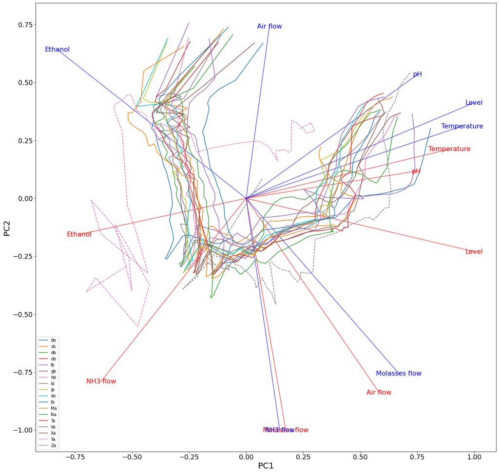

```python
plt.rcParams["figure.figsize"] = [20,20]
myplot(Bakers_scores[:,:2], Bakers_loadings_pd.iloc[:,:2],
        loading_labels = Bakers_loadings_pd.index,
        score_labels = Bakers_scores_pd.index)
myPlot(TB_scores[:,:2], TB_loadings_pd.iloc[:,:2],
       loading_labels = TB_loadings_pd.index,
       score_labels = TB_scores_pd.index)
plt.legend()
plt.show()
```